# R Exercise for KSE525

## Association Rule Tutorial in R

- In this tutorial, we will learn how to:
  - Load data and essential libraries
  - Explore and understand data
  - Preprocess and transform data before analysis
  - Analyze data using association rules
  - Visualize data mining results
- After tutorial, we will perform project to be fully aware of association rules

## Package and Data

```r
# Load package
library(arules) # association rules
library(arulesViz) # data visualization of association rules
library(RColorBrewer) # color palettes for plots
# Load data
data(Groceries) # grocery transactions object from arules package
# Check loaded data
print(dim(Groceries)) # number of baskets and items in them
```

```
[1] 9835  169
```

```r
print(dim(Groceries)[1]) # 9835 market baskets for shopping trips
```

```
[1] 9835
```

```r
print(dim(Groceries)[2]) # 169 initial store items
```

```
[1] 169
```

## Plot Item Frequency

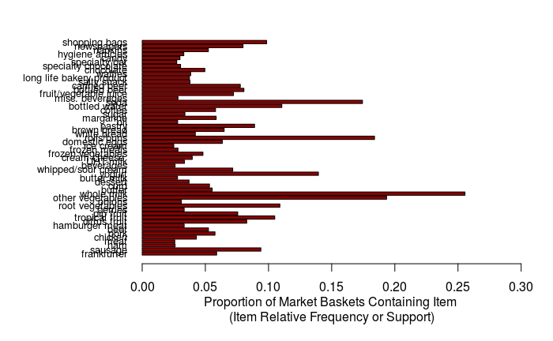

```r
# Plot item frequency
itemFrequencyPlot(Groceries, support = 0.025, cex.names = 0.8, xlim = c(0,0.3), type = "relative", horiz = TRUE, col = "dark red", las = 1, xlab = paste("Proportion of Market Baskets Containing Item", "\n(Item Relative Frequency or Support)"))
```

## Explore Data

```r
print(head(itemInfo(Groceries)))
```

|  | labels | level2 | level1 |
| --- | --- | --- | --- |
| 1 | frankfurter | sausage | meat and sausage |
| 2 | sausage | sausage | meat and sausage |
| 3 | liver loaf | sausage | meat and sausage |
| 4 | ham | sausage | meat and sausage |
| 5 | meat | sausage | meat and sausage |
| 6 | finished products | sausage | meat and sausage |

```r
print(levels(itemInfo(Groceries)[["level1"]]))  # 10 distinct levels
```

```
 [1] "canned food"          "detergent"            "drinks"               "fresh products"
 [5] "fruit and vegetables" "meat and sausage"     "non-food"             "perfumery"
 [9] "processed food"       "snacks and candies"
```

```r
print(levels(itemInfo(Groceries)[["level2"]])) # 55 distinct levels
```

```
 [1] "baby food"                       "bags"                            "bakery improver"
 [4] "bathroom cleaner"                "beef"                            "beer"
 [7] "bread and backed goods"          "candy"                           "canned fish"
[10] "canned fruit/vegetables"         "cheese"                          "chewing gum"
[13] "chocolate"                       "cleaner"                         "coffee"
[16] "condiments"                      "cosmetics"                       "dairy produce"
[19] "delicatessen"                    "dental care"                     "detergent/softener"
[22] "eggs"                            "fish"                            "frozen foods"
[25] "fruit"                           "games/books/hobby"               "garden"
[28] "hair care"                       "hard drinks"                     "health food"
[31] "jam/sweet spreads"               "long-life bakery products"       "meat spreads"
[34] "non-alc. drinks"                 "non-food house keeping products" "non-food kitchen"
[37] "packaged fruit/vegetables"       "perfumery"                       "personal hygiene"
[40] "pet food/care"                   "pork"                            "poultry"
[43] "pudding powder"                  "sausage"                         "seasonal products"
[46] "shelf-stable dairy"              "snacks"                          "soap"
[49] "soups/sauces"                    "staple foods"                    "sweetener"
[52] "tea/cocoa drinks"                "vegetables"                      "vinegar/oils"
[55] "wine"
```

## Data Preprocessing

```r
# Aggregate items using the 55 level2 levels for food categories to create a more meaningful set of items
groceries <- aggregate(Groceries, itemInfo(Groceries)[["level2"]])
print(dim(groceries)[1]) # 9835 market baskets for shopping trips
```

```
[1] 9835
```

```r
print(dim(groceries)[2]) # 55 final store items(categories)
```

```
[1] 55
```

## Plot Item Frequency

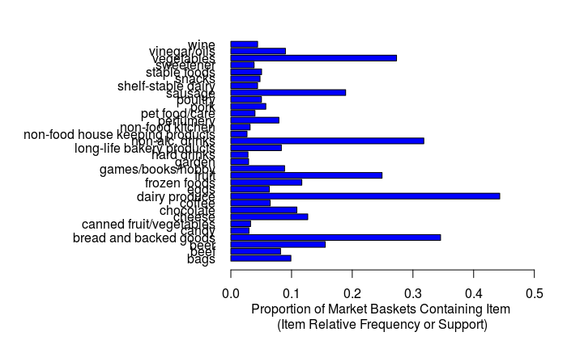

```r
# Plot item frequency
itemFrequencyPlot(groceries, support = 0.025, cex.names = 1.0, xlim = c(0,0.5), type = "relative", horiz = TRUE, col = "blue", las = 1, xlab = paste("Proportion of Market Baskets Containing Item", "\n(Item Relative Frequency or Support)"))
```

## Mine Association Rules

```r
# Obtain large set of association rules for items by category and all shoppers. This is done by setting very low criteria for support and confidence
first.rules <- apriori(groceries, parameter = list(support = 0.001, confidence = 0.05))
```

```
Apriori

Parameter specification:
 confidence minval smax arem  aval originalSupport maxtime support minlen maxlen target   ext
       0.05    0.1    1 none FALSE            TRUE       5   0.001      1     10  rules FALSE

Algorithmic control:
 filter tree heap memopt load sort verbose
    0.1 TRUE TRUE  FALSE TRUE    2    TRUE

Absolute minimum support count: 9

set item appearances ...[0 item(s)] done [0.00s].
set transactions ...[55 item(s), 9835 transaction(s)] done [0.00s].
sorting and recoding items ... [54 item(s)] done [0.00s].
creating transaction tree ... done [0.00s].
checking subsets of size 1 2 3 4 5 6 7 8 done [0.01s].
writing ... [69921 rule(s)] done [0.01s].
creating S4 object  ... done [0.01s].
```

```r
print(summary(first.rules)) # yields 69,921 rules
```

```
set of 69921 rules

rule length distribution (lhs + rhs):sizes
    1     2     3     4     5     6     7     8
   21  1205 10467 23895 22560  9888  1813    72

   Min. 1st Qu.  Median    Mean 3rd Qu.    Max.
  1.000   4.000   4.000   4.502   5.000   8.000

summary of quality measures:
    support           confidence          lift             count
 Min.   :0.001017   Min.   :0.0500   Min.   : 0.4475   Min.   :  10.00
 1st Qu.:0.001118   1st Qu.:0.2110   1st Qu.: 1.8315   1st Qu.:  11.00
 Median :0.001525   Median :0.4231   Median : 2.2573   Median :  15.00
 Mean   :0.002488   Mean   :0.4364   Mean   : 2.5382   Mean   :  24.47
 3rd Qu.:0.002339   3rd Qu.:0.6269   3rd Qu.: 2.9662   3rd Qu.:  23.00
 Max.   :0.443010   Max.   :1.0000   Max.   :16.1760   Max.   :4357.00

mining info:
      data ntransactions support confidence
 groceries          9835   0.001       0.05
```

```r
# Prune meaningless association rules using thresholds for support and confidence
second.rules <- apriori(groceries, parameter = list(support = 0.025, confidence = 0.05))
```

```
Apriori

Parameter specification:
 confidence minval smax arem  aval originalSupport maxtime support minlen maxlen target   ext
       0.05    0.1    1 none FALSE            TRUE       5   0.025      1     10  rules FALSE

Algorithmic control:
 filter tree heap memopt load sort verbose
    0.1 TRUE TRUE  FALSE TRUE    2    TRUE

Absolute minimum support count: 245

set item appearances ...[0 item(s)] done [0.00s].
set transactions ...[55 item(s), 9835 transaction(s)] done [0.00s].
sorting and recoding items ... [32 item(s)] done [0.00s].
creating transaction tree ... done [0.00s].
checking subsets of size 1 2 3 4 done [0.00s].
writing ... [344 rule(s)] done [0.00s].
creating S4 object  ... done [0.00s].
```

```r
print(summary(second.rules)) # yields 344 rules
```

```
set of 344 rules

rule length distribution (lhs + rhs):sizes
  1   2   3   4
 21 162 129  32

   Min. 1st Qu.  Median    Mean 3rd Qu.    Max.
    1.0     2.0     2.0     2.5     3.0     4.0

summary of quality measures:
    support          confidence           lift            count
 Min.   :0.02542   Min.   :0.05043   Min.   :0.6669   Min.   : 250.0
 1st Qu.:0.03030   1st Qu.:0.18202   1st Qu.:1.2498   1st Qu.: 298.0
 Median :0.03854   Median :0.39522   Median :1.4770   Median : 379.0
 Mean   :0.05276   Mean   :0.37658   Mean   :1.4831   Mean   : 518.9
 3rd Qu.:0.05236   3rd Qu.:0.51271   3rd Qu.:1.7094   3rd Qu.: 515.0
 Max.   :0.44301   Max.   :0.79841   Max.   :2.4073   Max.   :4357.0

mining info:
      data ntransactions support confidence
 groceries          9835   0.025       0.05
```

## Plot Association Rules

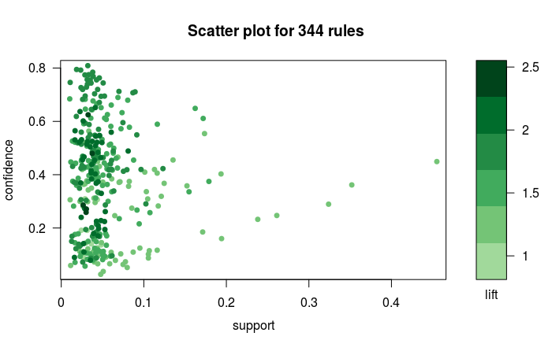

```r
# Data visualization of association rules in scatter plot
# arulesViz, RColorBrewer packages are used here
plot(second.rules, control=list(jitter = 2, col = rev(brewer.pal(9, "Greens")[4:9])), shading = "lift")
```

## Select Meaningful Rules

```r
# Select rules with vegetables in consequent (right-hand-side) item subsets
vegie.rules <- subset(second.rules, subset = rhs %pin% "vegetables")
# %pin% is the function which uses keyword to subset
inspect(vegie.rules) # 41 rules
```

```
     lhs                                                       rhs          support    confidence lift      count
[1]  {}                                                     => {vegetables} 0.27300458 0.2730046  1.0000000 2685
[2]  {poultry}                                              => {vegetables} 0.02897814 0.5745968  2.1047148  285
[3]  {pork}                                                 => {vegetables} 0.03009659 0.5220459  1.9122238  296
[4]  {staple foods}                                         => {vegetables} 0.02613116 0.5160643  1.8903136  257
[5]  {eggs}                                                 => {vegetables} 0.03141840 0.4951923  1.8138608  309
[6]  {games/books/hobby}                                    => {vegetables} 0.02785968 0.3145809  1.1522918  274
[7]  {long-life bakery products}                            => {vegetables} 0.02907982 0.3492063  1.2791227  286
[8]  {perfumery}                                            => {vegetables} 0.03213015 0.4056483  1.4858662  316
[9]  {beef}                                                 => {vegetables} 0.04585663 0.5595533  2.0496116  451
[10] {bags}                                                 => {vegetables} 0.03141840 0.3175745  1.1632571  309
[11] {vinegar/oils}                                         => {vegetables} 0.04199288 0.4666667  1.7093731  413
[12] {chocolate}                                            => {vegetables} 0.03192679 0.2934579  1.0749195  314
[13] {beer}                                                 => {vegetables} 0.03406202 0.2189542  0.8020168  335
[14] {frozen foods}                                         => {vegetables} 0.04738180 0.4052174  1.4842879  466
```

[output cut: 27 more lines]

```r
# Sort by lift and identify the top 10 rules
top.10.vegie.rules <- head(sort(vegie.rules, decreasing = TRUE, by = "lift"), 10)
inspect(top.10.vegie.rules)
```

```
     lhs                                             rhs          support    confidence lift     count
[1]  {beef,dairy produce}                         => {vegetables} 0.02989324 0.6074380  2.225010 294
[2]  {poultry}                                    => {vegetables} 0.02897814 0.5745968  2.104715 285
[3]  {dairy produce,fruit,sausage}                => {vegetables} 0.02714794 0.5741935  2.103238 267
[4]  {beef}                                       => {vegetables} 0.04585663 0.5595533  2.049612 451
[5]  {dairy produce,vinegar/oils}                 => {vegetables} 0.03141840 0.5355286  1.961610 309
[6]  {fruit,sausage}                              => {vegetables} 0.03426538 0.5290424  1.937852 337
[7]  {bread and backed goods,dairy produce,fruit} => {vegetables} 0.04077275 0.5276316  1.932684 401
[8]  {pork}                                       => {vegetables} 0.03009659 0.5220459  1.912224 296
[9]  {cheese,fruit}                               => {vegetables} 0.02674123 0.5197628  1.903861 263
[10] {dairy produce,fruit,non-alc. drinks}        => {vegetables} 0.03304525 0.5183413  1.898654 325
```

[output not shown]

[output not shown]

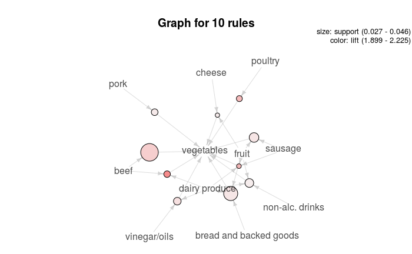

```r
plot(top.10.vegie.rules, method="graph", control=list(type="items"), shading = "lift")
```

## Project: Hard Drinks

- To see what people buy before hard drinks are purchased, we will do:
  - Load data and essential libraries(arules, arulesViz, RColorBrewer)
  - Make a new dataset ‘groceries’ aggregating item categories of Groceries itemsets into 55 categories; Level 1 has 10 categories, level 2 has 55 categories
  - Plot item frequency with support 0.001 using itemFrequencyPlot() function in ‘blue’ color
  - Create association rules using Apriori() function with support 0.001 and confidence 0.05
  - Plot the association rules in ‘Reds’ color using plot() function
  - Extract transactions including hard drinks on the right side using subset() function; ‘hard drinks’ is one of 55 item categories in Groceries itemset level 2
  - Sort by the lift measure and print the top 5 association rules using head() function
  - Identify which item is included in all rules in the left side after listing all rules using inspect() function and explain whether it is important or not
  - Plot a graph of the top 5 rules using plot()
  - Analyze whether the derived 5 rules are important based on appropriate measures(lift, confidence, support) or other reasons
- Append a code chunk and text to include:
  - 3 plots
  - Common item category in the left side of top 5 association rules and explanation whether that category is important related to ‘hard drinks’ category
  - Association rule, support, confidence, lift measure, count value from the top 5 association rules
  - Reasons whether the top 5 association rules are important or not based on the measures or other reasons